# Pricing II: Aplicación de R a la tarificación

- Show All Code
- Hide All Code
- View Source

Author

Carolina Armella, Ágatha del Olmo y María Yu García

Published

October 18, 2024

## 1. Introducción

El hundimiento del Titanic en su viaje inaugural el 15 de abril de 1912 es uno de los naufragios más emblemáticos de la historia moderna. Esta tragedia, que costó la vida a más de 1.500 personas, no solo marcó un punto de inflexión en la seguridad marítima, sino que también ofrece un fascinante escenario para el análisis estadístico y predictivo.

En este trabajo, utilizaremos el conjunto de datos del Titanic para desarrollar un modelo que permita predecir la probabilidad de supervivencia de los pasajeros basándonos en sus características individuales. Mediante técnicas de análisis de datos y aprendizaje automático, exploraremos cómo factores como la clase socioeconómica, el género, la edad y la composición familiar influyeron decisivamente en las posibilidades de sobrevivir a este trágico evento.

Nuestro objetivo es comprender los patrones que determinaron la supervivencia en una de las catástrofes marítimas más conocidas del siglo XX utilizando herramientas como los árboles de decisión que nos permitan transformar datos históricos en información significativa y predictiva.

## 2. Datos

```r
datos <- read.csv("./Datos Titanic.csv", sep = ";", dec = ".", header = T)
```

```r
head(datos)
```

```
  pclass survived                        name    sex age sibsp parch   ticket
1      1        0    Baxter, Mr. Quigg Edmond   male  24     0     1 PC 17558
2      1        1       Behr, Mr. Karl Howell   male  26     0     0   111369
3      1        1           Bird, Miss. Ellen female  29     0     0 PC 17483
4      1        0          Brandeis, Mr. Emil   male  48     0     0 PC 17591
5      1        0      Carrau, Mr. Jose Pedro   male  17     0     0   113059
6      1        1 Chaudanson, Miss. Victorine female  36     0     0 PC 17608
      fare   cabin embarked boat body           home.dest
1 247.5208 B58 B60        C <NA>   NA        Montreal, PQ
2  30.0000    C148        C    5   NA        New York, NY
3 221.7792     C97        S    8   NA                <NA>
4  50.4958     B10        C <NA>  208           Omaha, NE
5  47.1000    <NA>        S <NA>   NA Montevideo, Uruguay
6 262.3750     B61        C    4   NA                <NA>
```

El conjunto de datos lo dividimos en dos subconjuntos, training set y test set.

**Separación del dataset**

```r
# Permutamos los datos al azar
set.seed(216514)
azar <- sample(1:nrow(datos))
casos <- round(nrow(datos)*0.667)

titanic_train <- datos[azar[1:casos],]
titanic_test <- datos[azar[(casos+1):nrow(datos)],]

Tabla.Training <- table(titanic_train$survived)
Tabla.Test <- table(titanic_test$survived)
```

```r
Tabla.Training %>%
  kbl(col.names = c("Supervivencia", "Frecuencia"),
      align = rep('c', 2)) %>%
  kable_styling()
```

| Supervivencia | Frecuencia |
| --- | --- |
| 0 | 532 |
| 1 | 341 |

```r
Tabla.Test %>%
  kbl(col.names = c("Supervivencia", "Frecuencia"),
      align = rep('c', 2)) %>%
  kable_styling()
```

| Supervivencia | Frecuencia |
| --- | --- |
| 0 | 277 |
| 1 | 159 |

### 2.1 Tratamiento previo de los datos

Antes de proceder con el análisis predictivo, es crucial realizar una serie de pasos para preparar el conjunto de datos del Titanic para su análisis y modelado.

En este caso, dado que no es el objetivo principal, omitimos tanto el análisis exploratorio de datos (EDA) como gran parte del tratamiento previo.

No obstante, es evidente que la variable respuesta está influenciada por factores como el sexo, el puerto de embarque, la clase del pasajero, el precio del billete (estrechamente relacionado con la clase), la edad y el número de familiares que viajaban juntos, entre otros.

Antes de abordar la resolución del problema, es fundamental plantearnos las siguientes preguntas:

¿Incluiremos todas las variables disponibles en el modelo? ¿Están todas las variables correctamente definidas según su tipo? ¿Cómo manejaremos los valores faltantes (NA’s)? Esto nos permitirá estructurar adecuadamente el análisis y asegurar un enfoque consistente y robusto.

### 2.2 Selección y transformación de variables

Para optimizar nuestro análisis, hemos decidido eliminar algunas variables que consideramos menos relevantes o potencialmente problemáticas para el modelado.

Además, hemos realizado transformaciones importantes en algunas variables: La variable ‘Pclass’ (clase de pasajero) se ha convertido en un factor con niveles más descriptivos: ‘Upper’, ‘Middle’ y ‘Lower’; y la variable ‘Survived’ se ha transformado en un factor con las etiquetas ‘Died’ y ‘Survived’.

En cuanto al tratamiento de los valores faltantes (NA’s), hemos optado por eliminar las filas que contienen cualquier valor NA.

Echamos un vistazo a las correlaciones para decidir si eliminar alguna otra variable:

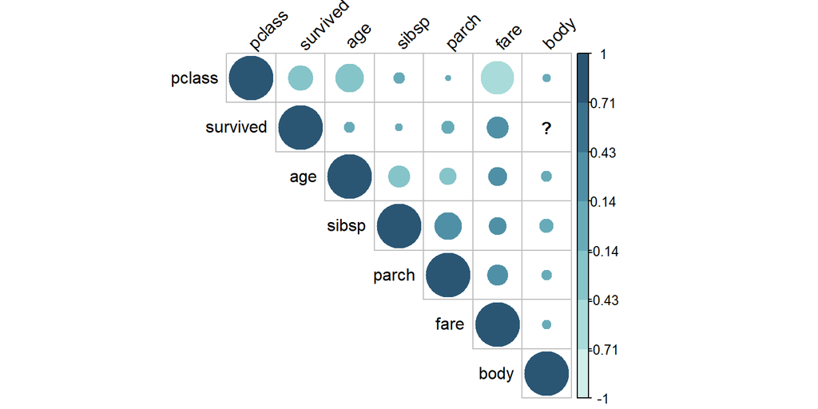

```r
numericas <- datos[sapply(datos, is.numeric)]

correlaciones <- cor(numericas, use = "pairwise.complete.obs")

corrplot(correlaciones, method = "circle", type = "upper",
         tl.col = "black", tl.srt = 45, col = colores)
```

Al haber una alta correlación entre fare (precio del pagado por el billete) y la clase decidimos también eliminar la variable fare ya que nos dan una información muy similar (a mayor clase mayor era el precio pagado por el billete).

```r
train <- titanic_train %>%
  dplyr::select(-c(body, boat, name, cabin, ticket, home.dest, fare)) %>%
  mutate(pclass = factor(pclass,
                         levels = c(1, 2, 3),
                         labels = c('Upper', 'Middle',
                                    'Lower')),
         survived = factor(survived,
                           levels = c(0, 1),
                           labels = c('Died', 'Survived')))%>%
  na.omit()

glimpse(train)
```

```
Rows: 697
Columns: 7
$ pclass   <fct> Upper, Middle, Upper, Upper, Upper, Upper, Lower, Lower, Midd…
$ survived <fct> Died, Survived, Survived, Survived, Survived, Survived, Died,…
$ sex      <chr> "male", "female", "female", "female", "female", "female", "ma…
$ age      <dbl> 45.5, 40.0, 24.0, 54.0, 51.0, 60.0, 22.0, 33.0, 22.0, 18.5, 1…
$ sibsp    <int> 0, 1, 0, 1, 1, 0, 0, 0, 2, 0, 0, 0, 0, 0, 1, 0, 1, 0, 0, 1, 0…
$ parch    <int> 0, 1, 0, 0, 0, 0, 0, 0, 0, 0, 2, 0, 0, 1, 2, 1, 1, 0, 0, 1, 0…
$ embarked <chr> "S", "S", "C", "C", "S", "C", "S", "S", "S", "Q", "S", "S", "…
```

```r
test <- titanic_test %>%
  dplyr::select(-c(body, boat, name, cabin, ticket, home.dest, fare)) %>%
  mutate(pclass = factor(pclass,
                         levels = c(1, 2, 3),
                         labels = c('Upper', 'Middle',
                                    'Lower')),
         survived = factor(survived,
                           levels = c(0, 1),
                           labels = c('Died', 'Survived')))%>%
  na.omit()

glimpse(test)
```

```
Rows: 347
Columns: 7
$ pclass   <fct> Lower, Lower, Upper, Middle, Lower, Middle, Lower, Lower, Low…
$ survived <fct> Died, Survived, Survived, Died, Died, Survived, Survived, Die…
$ sex      <chr> "male", "male", "female", "male", "male", "female", "female",…
$ age      <dbl> 44.00, 39.00, 26.00, 49.00, 20.00, 20.00, 0.75, 22.00, 27.00,…
$ sibsp    <int> 0, 0, 0, 1, 0, 2, 2, 0, 1, 1, 0, 0, 0, 0, 3, 0, 0, 0, 0, 0, 2…
$ parch    <int> 0, 1, 0, 2, 0, 1, 1, 0, 0, 0, 0, 0, 0, 0, 1, 0, 0, 0, 0, 0, 0…
$ embarked <chr> "S", "C", "S", "S", "C", "S", "C", "S", "S", "Q", "S", "S", "…
```

Esta decisión implica tanto ventajas como desventajas. Por un lado, nos permite trabajar con un conjunto de datos completo, evitando complicaciones en el análisis y modelado posteriores. Sin embargo, puede resultar en una pérdida significativa de datos, potencialmente introduciendo sesgos si los valores faltantes no son aleatorios.

Es importante notar que esta eliminación reduce nuestro conjunto de entrenamiento de 873 a 697 observaciones, y el conjunto de prueba de 436 a 347 observaciones.

## 3. Construcción de los árboles

En esta sección, nos enfocamoremos en la construcción y visualización de un modelo de árbol de decisión para predecir la supervivencia de los pasajeros.

Vamos a utilizar la librería rpart, que implementa el algoritmo CART (Classification and Regression Trees).

```r
arbol <- rpart(survived ~ ., data = train, method = 'class')
```

Empleamos la función rpart.plot para visualizar el árbol de decisión de diferentes maneras. Mediante el número que pongamos en el argumento extra podemos controlar qué detalles adicionales se incluyen en los nodos.

### 3.1 Modelo por defecto

Construimos un arbol empleando las opciones por defecto. Entre otras características emplea la medida de Gini para determinar las particiones en cada nodo.

**Índice de Gini**

Mide la pureza de los nodos después de una división. Cuanto menor es el índice, mayor es la pureza del nodo (es decir, los elementos en el nodo tienden a pertenecer a una sola clase).

El argumento extra controla qué información adicional se muestra en cada nodo del árbol según el valor que le des:

- extra = 0: No muestra información adicional.
- extra = 1: Muestra el número de observaciones en el nodo según la división.
- extra = 2: En modelos de clasificación, muestra la tasa de clasificación correcta en el nodo.
- extra = 3: Muestra la tasa de error en el nodo (clasificaciones incorrectas).
- extra = 4: Muestra las probabilidades de cada clase en el nodo.
- extra = 5: Igual que 4, pero no muestra la clase predicha en el nodo.
- extra = 6: Probabilidad de la segunda clase.
- extra = 7: Igual que 6, pero sin mostrar la clase predicha.
- extra = 8: Probabilidad de la clase predicha en el nodo.
- extra = 9: Probabilidad relativa a todas las observaciones.
- extra = 10: Igual que 9, pero muestra solo la probabilidad de la segunda clase.
- extra = 11: Igual que 10, pero sin mostrar la clase predicha.

Además, añadirle a cada valor 100 incluye el porcentaje de observaciones en el nodo. Podemos verlo en los siguientes ejemplos:

Con extra = 101 obtenemos el número y el porcentaje de observaciones en cada nodo (proporción del total de datos que llegan al nodo) y la clase predicha (con threshoold 0.5).

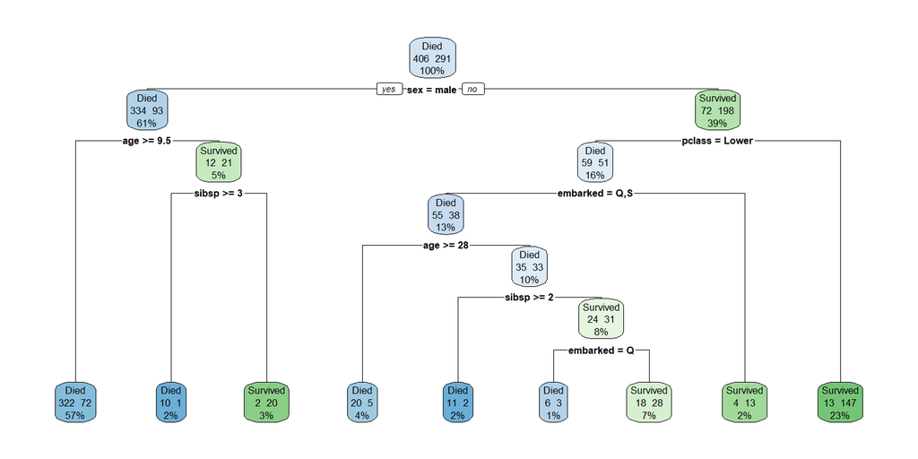

```r
rpart.plot(arbol, extra = 101)
```

En cambio, con extra = 1 solo nos muestra el número de observaciones de cada clase dentro del nodo.

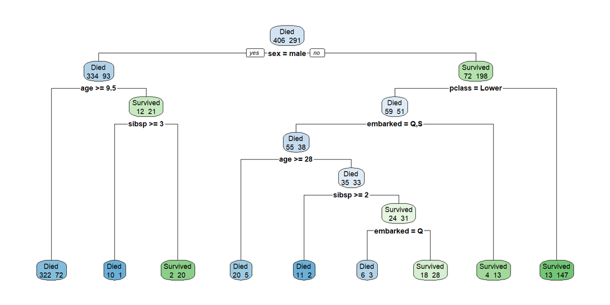

```r
rpart.plot(arbol, extra = 1)
```

Con extra = 9 conseguimos la probabilidad relativa de todas las observaciones en el nodo o probabilidad global, lo que significa que muestra las probabilidades de las clases en cada nodo del árbol en lugar de mostrar la probabilidad condicionada dentro del nodo. De hecho, podemos comprobar que todas las probabilidades sumadas dan 1.

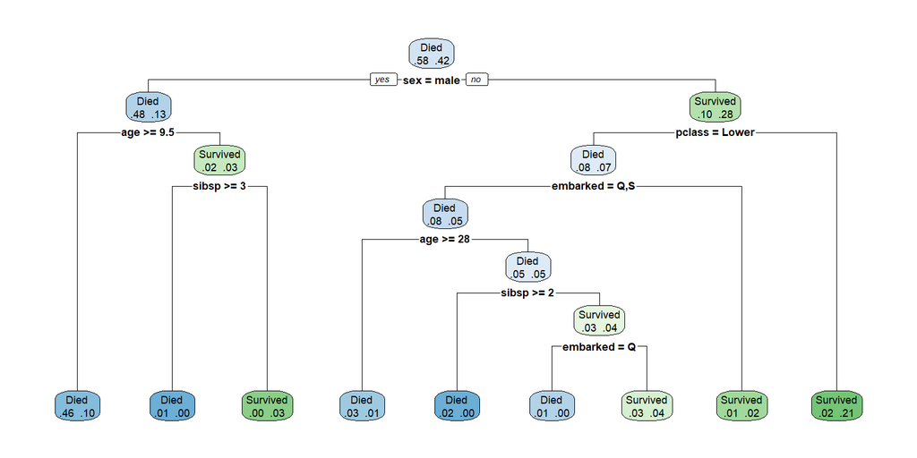

```r
rpart.plot(arbol, extra = 9)
```

En la propia construcción del árbol no observamos ningún cambio ya que parte del mismo árbol, lo único que cambia es la información adicional que se prové en los nodos finales.

Como podemos ver, los árboles de decisión tienen varias ventajas, entre ellas, como vemos, ser fácilmente interpretables. Además, desde el punto de vista de pre-procesamiento de datos, requieren muy poca preparación previa. Por ejemplo, no requieren escalamiento o centrado de variables.

### 3.1 Modelos con diferente subconjunto de datos

En cambio, cabe destacar que los árboles de decisión son muy sensibles al conjunto de datos específico utilizado para el entrenamiento. Además, su baja robustez hace que pequeños cambios en los datos puedan resultar en árboles significativamente diferentes.

Podemos observar el siguiente ejemplo en el que escogemos solo las 500 primeras observaciones del training set:

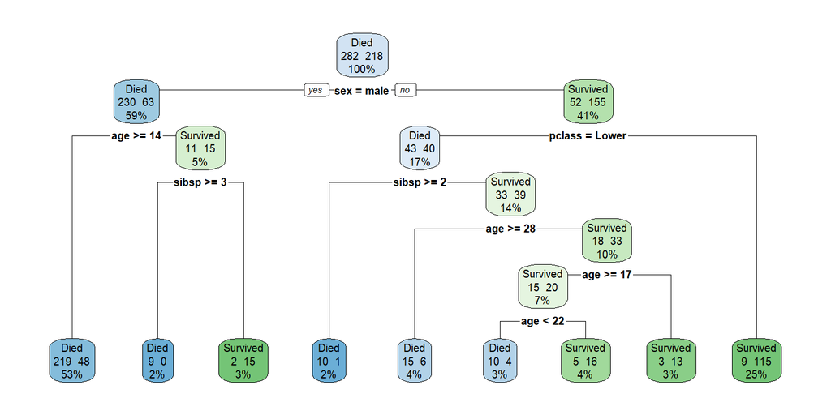

```r
arbol2 <- rpart(survived ~ ., data = train[1:500, ], method = 'class')

rpart.plot(arbol2, extra = 101)
```

Al comparar este árbol con el primero, notamos que, al utilizar solo las primeras 500 observaciones en el segundo árbol, los umbrales elegidos para las variables cambian significativamente.

Por ejemplo, para los hombres, en edad, el umbral pasa de >= 9.5 en el primer árbol a >= 14 en el segundo. Para las mujeres de clase baja cambia el resto de nodos menos por Edad >= 0 28.

Estos cambios en los umbrales podrían ser el resultado de que el segundo árbol, al trabajar con un subconjunto más pequeño de datos (las primeras 500 observaciones), ajusta de manera diferente las particiones, adaptándose mejor a las características de ese subconjunto específico.

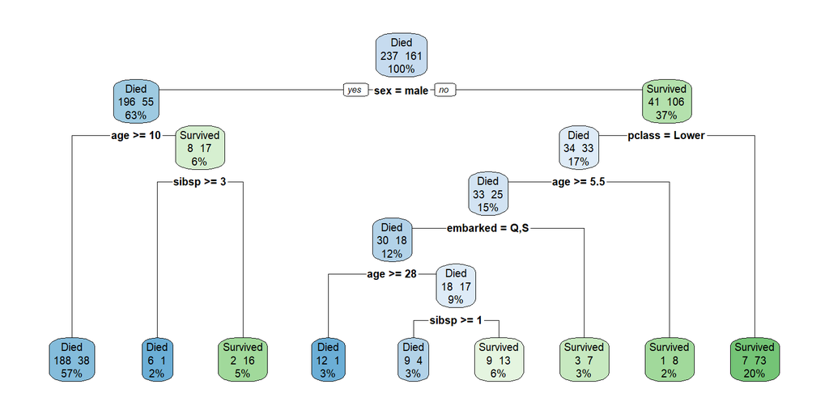

```r
arbol3 <- rpart(survived ~ ., data = train[300:800, ], method = 'class')

rpart.plot(arbol3, extra = 101)
```

Tal como podemos cambiar el subconjunto, podemos ajustar los hiperparámetros que incluimos en la solución. Por ejemplo:

**Otros argumentos**

- minsplit: Número mínimo de observaciones en un nodo para intentar una división.
- minbucket: Número mínimo de observaciones en cualquier nodo terminal.
- maxdepth: Profundidad máxima del árbol.
- cp: Parámetro de complejidad para la poda.

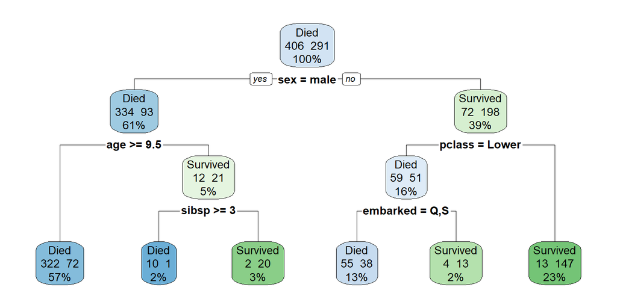

```r
control <- rpart.control(minsplit = 4,
    minbucket = round(7/3),
    maxdepth = 3,
    cp = 0)

arbol4 <- rpart(survived ~ ., data = train, method = 'class', control = control)

rpart.plot(arbol4, extra = 101)
```

En este árbol usamos un mínimo de observaciones en un nodo para dividir de 4, un mínimo de observaciones en cualquier nodo terminal de 7/3 que redondeado es 2, un máximo de profundidad de 3 y una complejidad 0.

Como vemos, el árbol se simplifica mucho. Ahora solo conseguimos 6 nodos terminales gracias a la profundidad 3 y posiblemente gracias al resto de hiperparámetros.

### 3.2 Modelos con Postprunning

Aunque es interesante el método anterior, no deja de ser arbitrario, en camvio, podemos utilizar la técnica del Postprunning, de forma que dejamos crecer un árbol completo con cp = 0, examinamos el parámetro de complejidad (cp) óptimo y finalmente podamos el árbol utilizando el cp óptimo.

Primero, se ajusta un árbol de decisión con el parámetro cp = 0, lo que significa que el árbol crecerá sin restricciones y tendrá una estructura muy detallada (puede que hasta sobreajustada).

```r
arbol5 <- rpart(survived ~ ., data = train, method = "class",
                control = rpart.control(cp = 0))
```

El parámetro cp óptimo (mínimo) se encuentra observando la tabla generada, que muestra el valor de cp para cada nodo del árbol. Este valor se utiliza para encontrar el punto de poda que balancea el ajuste del modelo y evita el sobreajuste.

```r
printcp(arbol5)
```

```
Classification tree:
rpart(formula = survived ~ ., data = train, method = "class",
    control = rpart.control(cp = 0))

Variables actually used in tree construction:
[1] age      embarked pclass   sex      sibsp

Root node error: 291/697 = 0.4175

n= 697

         CP nsplit rel error  xerror     xstd
1 0.4329897      0   1.00000 1.00000 0.044740
2 0.0309278      1   0.56701 0.56701 0.038565
3 0.0292096      3   0.50515 0.58419 0.038960
4 0.0120275      5   0.44674 0.50859 0.037103
5 0.0103093      7   0.42268 0.50859 0.037103
6 0.0017182      8   0.41237 0.51546 0.037285
7 0.0011455     15   0.39863 0.53952 0.037900
8 0.0000000     18   0.39519 0.55326 0.038237
```

El valor más bajo de xerror (0.50859) corresponde al valor de cp 0.0103093 y 0.0120275. De todas formas, este valor puede ser demasiado pequeño y permitir sobreajuste. Lo vemos en un gráfico que muestra el el error cruzado a lo largo del árbol:

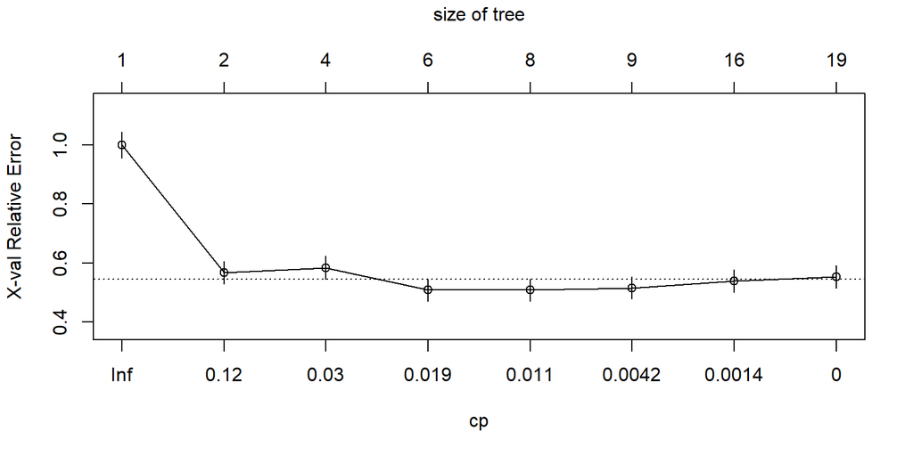

```r
plotcp(arbol5)
```

Comparamos el uso de cada uno de los cp que reducen el error cruzado al mismo nivel:

```r
arbol5_pruned1 <- prune(arbol5, cp = 0.0103093)
arbol5_pruned2 <- prune(arbol5, cp = 0.0120275)
```

Vemos primero el árbol sin Postprunning:

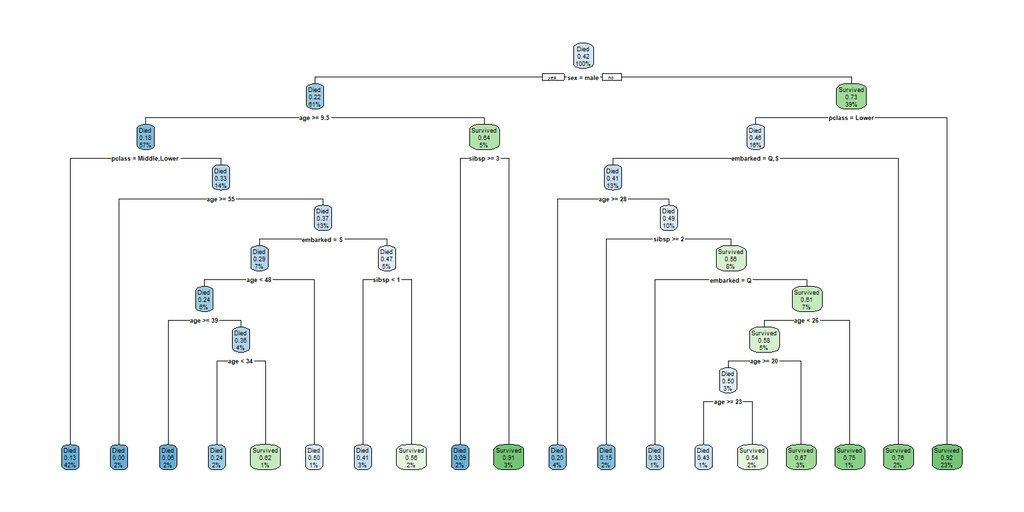

```r
rpart.plot(arbol5)
```

Claramente, el árbol está extremadamente sobreajustado y el modelo no tendría un buen desempeño de usarse con datos externos.

Utilizando el nuevo modelo podado obtenemos el siguiente árbol:

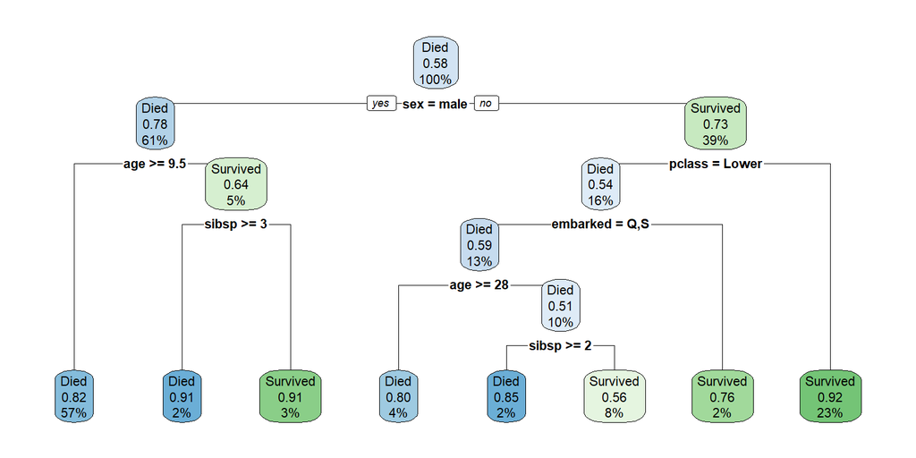

```r
rpart.plot(arbol5_pruned1, extra=108)
```

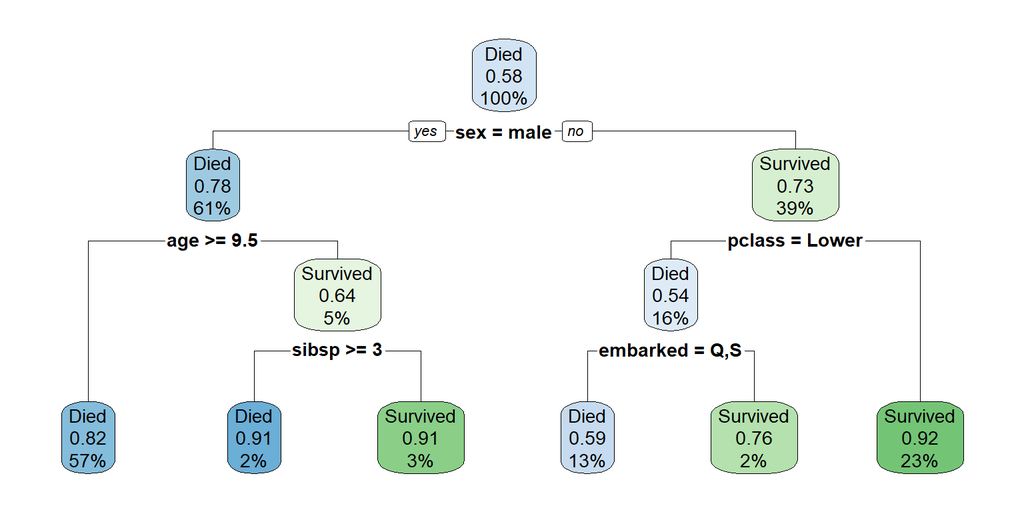

```r
rpart.plot(arbol5_pruned2, extra=108)
```

Como vemos, cada uno nos da un resultado muy diferente cambiando el hiperparámetro de complejidad únicamente en 0.002 puntos.

## 4. Evaluación y predicción de los modelos

A continuación, nos enfocaremos en la predicción, evaluación y ajuste del modelo de árbol de decisión para el problema de supervivencia del Titanic.

Tras hacerlo, elegiremos los mejores modelos para interpretar sus árboles.

### 4.1 Evaluación de los modelos

```r
predict_test <-predict(arbol, test, type = 'class')

predict_test2 <-predict(arbol2, test, type = 'class')

predict_test3 <-predict(arbol3, test, type = 'class')

predict_test4 <-predict(arbol4, test, type = 'class')

predict_test51 <-predict(arbol5_pruned1, test, type = 'class')

predict_test52 <-predict(arbol5_pruned2, test, type = 'class')
```

**Mostrar código**

```r
metricas <- function(modelo_func, test, true_labels) {

  prediccion_test_func <- predict(modelo_func, test, type = 'class')

    conf_func <- confusionMatrix(prediccion_test_func, true_labels)


    resultados <- data.frame(
    Metric = c("Accuracy", "Error Rate", "Kappa", "Sensitivity",
               "Specificity", "F1 Score"),
    Value = c(conf_func$overall['Accuracy'],
              1 - conf_func$overall['Accuracy'],
              conf_func$overall['Kappa'],
              conf_func$byClass['Sensitivity'],
              conf_func$byClass['Specificity'],
              conf_func$byClass['F1'])
  )

  return(resultados)
}
```

Recordamos qué significa cada una de las métricas:

**Métricas de evaluación**

La precisión nos indica cuánto hemos acertado en un sentido global, es decir, cuán cerca estuvieron las predicciones de la realidad. $Accuracy=\frac{TP+TN}{TP+TN+FP+FN}$

La tasa de error indica cuánto nos hemos equivocado en sentido global, contrario al accuracy. $Error\space rate=\frac{FP+FN}{TP+TN+FP+FN}$

La métrica Kappa mide la diferencia entre $P_o$ y $P_e$, de forma que si $Kappa=0$, entonces la coincidencia entre predicciones y observaciones es producto del azar, mientras que si $Kappa=1$, el modelo ha conseguido una coincidencia perfecta por encima del azar. $kappa=\frac{(po-pe)}{(1-pe)}$

El F-score es una media ponderada harmónica entre precisión y sensibilidad que define qué tan bien el modelo equilibra ambos aspectos para evaluar su rendimiento general. $Fscore = \frac{2}{\frac{1}{Precision}+\frac{1}{sensibilidad}}$

```r
resultados <- metricas(arbol, test, test$survived)

resultados2 <- metricas(arbol2, test, test$survived)

resultados3 <- metricas(arbol3, test, test$survived)

resultados4 <- metricas(arbol4, test, test$survived)

resultados5 <- metricas(arbol5, test, test$survived)

resultados51 <- metricas(arbol5_pruned1, test, test$survived)

resultados52 <- metricas(arbol5_pruned2, test, test$survived)
```

```r
resultados$model <- "Arbol 1"
resultados2$model <- "Arbol 2"
resultados3$model <- "Arbol 3"
resultados4$model <- "Arbol 4"
resultados5$model <- "Arbol 5"
resultados51$model <- "Arbol 5 pruned 1"
resultados52$model <- "Arbol 5 Pruned 2"

todos_resultados <- rbind(resultados, resultados2, resultados3, resultados4, resultados5, resultados51, resultados52)

todos_resultados_largo <- pivot_wider(
  todos_resultados,
  names_from = model,
  values_from = Value
)

print(todos_resultados_largo)
```

```
# A tibble: 6 × 8
  Metric    `Arbol 1` `Arbol 2` `Arbol 3` `Arbol 4` `Arbol 5` `Arbol 5 pruned 1`
  <chr>         <dbl>     <dbl>     <dbl>     <dbl>     <dbl>              <dbl>
1 Accuracy      0.821     0.818     0.839     0.827     0.818              0.830
2 Error Ra…     0.179     0.182     0.161     0.173     0.182              0.170
3 Kappa         0.602     0.594     0.642     0.608     0.598              0.624
4 Sensitiv…     0.944     0.948     0.953     0.977     0.934              0.939
5 Specific…     0.627     0.612     0.657     0.590     0.634              0.657
6 F1 Score      0.866     0.865     0.879     0.874     0.863              0.871
# ℹ 1 more variable: `Arbol 5 Pruned 2` <dbl>
```

### 4.2 Elección de los mejores modelos

En resumen, el mejor modelo es el arbol3 ya que es el más equilibrado, con alta precisión, especificidad y F1 score, posiblemente porque casualmente usa un subconjunto más representativo de datos (observaciones 300 a 800).

Entre los modelos de poda, ambos ofrecen mejoras sobre el modelo no podado (arbol5), aunque no superan a arbol3. En cambio, el arbol4, que es el más simplificado, con un máximo de profundidad y restricciones más severas, logra alta sensibilidad, pero a costa de un peor desempeño en especificidad y precisión, por lo que no nos interesa tampoco sobrepodar.

### 4.3 Interpretación de los mejores modelos

Por lo tanto, vamos a interpretar el arbol3 y los dos últimos podados:

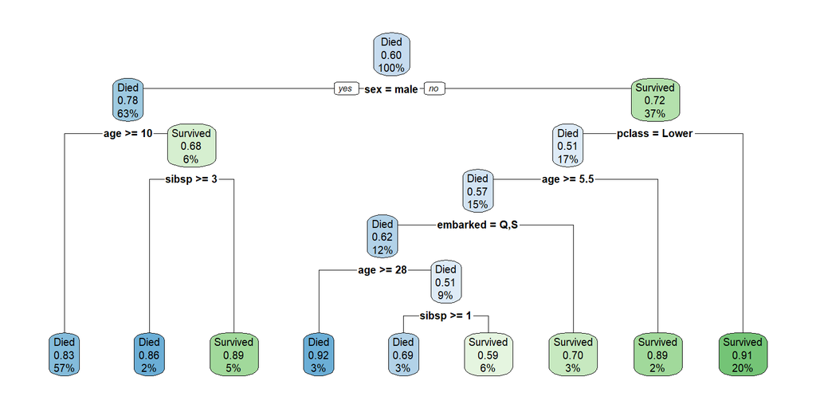

```r
rpart.plot(arbol3, extra = 108)
```

Según las predicciones de este árbol (arbol3), si eras hombre de 10 años o más tenías un 83% de probabilidades de morir, en cambio, si tenías menos de 10 años y 3 o más hermanos/hermanastros en el barco tenías un 86% de probabilidades de morir, mientras que si tenías menos de 3 hermanos/hermanastros en el barco tenías un 89% de probabilidades de sobrevivir.

En conclusión, según este árbol, si eras hombre lo mejor era tener 10 años o menos y tener menos de 3 hermanos a bordo. En cambio, si eras mujer, lo mejor que podías ser era de media o alta clase, o en caso de ser de baja clase tener menos de 5 años.

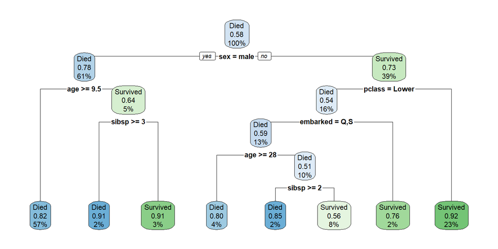

```r
rpart.plot(arbol5_pruned1, extra = 108)
```

Si eras mujer el árbol se desarrolla de forma también es muy similar. Si no eras de clase baja, directamente tenías un 92% de probabilidad de sobrevivir, en cambio, si eras de clase baja de nuevo se complica. Las mujeres de clase baja que no habían embarcado en S (Southampton) o en Q (Queenstown, actual Cobh) tenían una probabilidad de supervivencia del 76%. Si sí que habían embarcado en alguno de estos puertos y su edad era de 28 o mayor tenían una probabilidad del 80% de morir (0.12 puntos menos que según el anterior), en cambio si eran más jóvenes y no tenían máximo un hermano en el barco tenían un 56% de probabilidad de supervivencia, mientras que si tenían dos hermanos o más a bordo tenían un 85% de probabilidad de muerte (0.16 puntos más que en el anterior modelo).

En conclusión, según este árbol, si eras hombre de nuevo lo mejor era tener 10 años o menos y tener menos de 3 hermanos a bordo. En cambio, si eras mujer, lo mejor que podías ser era de clase media o alta, o en caso de ser de baja clase no haber embarcado en Southampton o Queenstown.

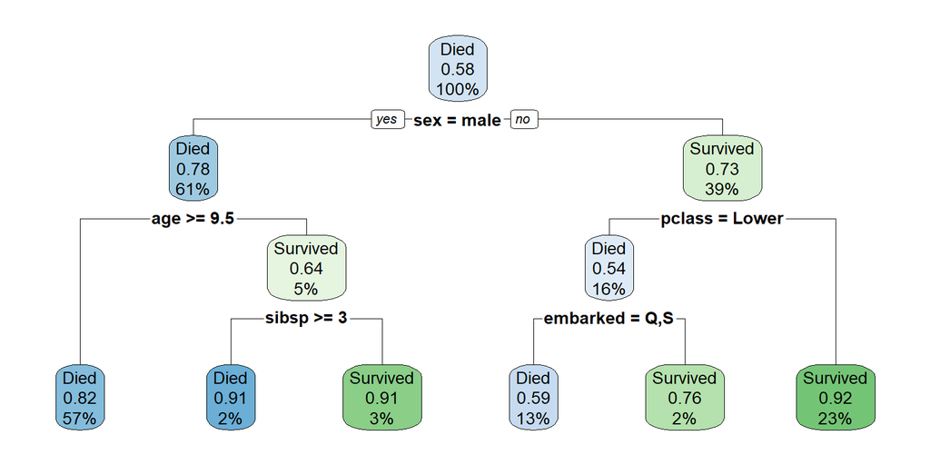

```r
rpart.plot(arbol5_pruned2, extra = 108)
```

Por último, tenemos el arbol 5 podado 2, que es el menos complicado de los tres con solo 6 nodos terminales. De nuevo para los hombres se desarrolla exactamente igual que el anterior.

De nuevo si eras mujer de clase media o alta tenías una probabilidad de supervivencia del 92%. En cambio, si eras de clase baja y habías embarcado en Southampton o Queenstown tenías un 59% de probabilidades de morir. Si habías embarcado en el puerto de Cherburgo siendo de clase baja tenías unas 76% de probabilidades de sobrevivir.

Llegamos a la misma conclusión según este árbol, si eras hombre de nuevo lo mejor era tener 10 años o menos y tener menos de 3 hermanos/hermanastros a bordo. En cambio, si eras mujer, lo mejor que podías ser era de media o alta clase, o en caso de ser de baja clase haber embarcado en Cherburgo.

Viendo los tres árboles, vemos que destacan patrones basados en normas sociales de la época. Las mujeres y los niños tenían más posibilidades de supervivencia debido a las prioridades de rescate, mientras que la clase social jugó un papel crucial en el acceso a los botes salvavidas. En cuanto a los pasajeros que embarcaron en Cherburgo, podrían haber tenido una ubicación algo más favorable dentro del barco, incluso en tercera clase, tal vez se encontraban más cerca de los botes salvavidas, o tal vez tenían camarotes en pisos menos bajos, lo cual les facilitaba evacuar más rápido. Esto refleja la desigualdad inherente en el contexto del Titanic y la relevancia de variables sociales en los resultados del naufragio.

## 5. Random Forest

Los árboles son modelos poco robustos: como hemos visto, son muy sensibles a los conjuntos de entrenamiento, aunque tienen muchas ventajas. Los bosques aleatorios pretenden aprovechar sus ventajas, reduciendo su variabilidad, mediante modelos de ensemble.

Los Random Forest tienen varios hiperparámetros de interés. El más importante de los hiperparámetros se considera que es el número de variables candidatas a considerar en cada ramificación.

La lista de los diferentes hiperparámetros del paquete randomForest incluye:

- Número de árboles en el bosque (ntree): se necesita un mínimo de árboles para estabilizar el error, pero usar demasiados árboles puede ser innecesariamente ineficiente, pues incrementa el coste computacional.
- Número de variables (features): a considerar como candidatas en cada ramifiación (mtry).
- Número de muestras sobre las cuales entrenar en cada ramificación (sampsize): el valor por defecto es 63.25%, ya que valores más bajos podrían introducir sesgo. En cambio, valores más altos podrían incrementar el rendimiento del modelo a riesgo de causar overfitting. Por lo tanto, generalmente se mantiene en el rango 60-80%.
- Número mínimo de muestras dentro de los nodos terminales (nodesize): Sirve para controlar el trade-off entre sesgo y varianza.
- Número máximo de nodos terminales (maxnodes): Sirve como prunning para evitar el sobreajuste.

Ventajas:

- No hay hipótesis a priori sobre las relaciones entre las variables.
- Bajo coste de preparación de datos.
- Una de las salidas del modelo es la importancia de los predictores.
- Puede manejar miles de variables de entrada, ayudando a identificar las más significativas. Es decir, puede ser empleado como un método de reducción de dimensionalidad.
- Suele implementar de manera automática un método para estimar valores faltantes.
- Es posible usarlo como método no supervisado (clustering) y detección de outliers.

Desventajas:

- Perdemos capacidad de interpretación respecto a lo que hace un único árbol.
- Suele funcionar mejor para problemas de clasificación que para predicciones numéricas. En regresión numérica sólo predice dentro del rango de valores del conjunto de entrenamiento.
- Los bosques aleatorios están sesgados hacia el empleo de factores que tienen múltiples niveles (categorías). Esto se debe a que la selección de características está basada en la * reducción de impurezas, por lo que la selección de variables (importancia) no suele ser precisa para este tipo de variables.
- Es un modelo que comienza a tener características de los algoritmos de caja negra.

### 5.3 Ajuste del modelo

Vamos a ajustar el modelo de Random Forest con la base de datos Fraud que nos guardamos anteriormente en la tarea 1. Nuestro principal objetivo es crear un modelo predictivo altamente preciso, capaz de identificar transacciones fraudulentas minimizando especialmente los falsos negativos.

Recordemos las características de la variable:

La base de datos utilizada contiene transacciones reales con tarjetas de crédito realizadas por europeos durante un período de dos días en septiembre de 2013. Incluye un total de 284807 transacciones, de las cuales solo 492 fueron clasificadas como fraudulentas, lo que representa apenas un 0.172% del total. Esta baja proporción de fraudes refleja un desequilibrio significativo en los datos.

Por otra parte, el conjunto de datos incluye variables numéricas que han sido transformadas mediante un Análisis de Componentes Principales (PCA), lo que significa que las variables originales relacionadas con las transacciones no son directamente accesibles por motivos de confidencialidad. Estas variables transformadas están etiquetadas como V1 a V28 y representan los principales componentes del PCA que explican la mayor parte de la variabilidad en los datos originales.

Además, hay dos características que no han sido transformadas:

- Time: Indica el tiempo en segundos transcurrido entre cada transacción y la primera transacción registrada.
- Amount: Representa el valor total de la transacción.

como el muestreo de la base de datos se realizó durante un período de dos días sin especificar qué días son, la variable pierde algo de relevancia en términos de su capacidad para identificar patrones relacionados con el tiempo del día, la semana, o eventos específicos. Sería interesante contar con una variable temporal más precisa que indique el día de la semana, la hora o incluso el mes, para explorar si hay patrones específicos relacionados con el día o la hora en que se realizan las transacciones, lo cual podría ayudar a identificar diferencias en el comportamiento entre los casos fraudulentos y no fraudulentos. Por esta razón, la gran parte del estudio ignoraremos esta variable.

Finalmente, la variable de respuesta, Class, toma valores binarios:

- 1 para las transacciones fraudulentas
- 0 para las transacciones legítimas

```r
load("C:/Users/Portatil/OneDrive - Universitat de Valencia/Escritorio/Universidad/3º BIA/1r CUATRIMESTRE/TECNICAS AVANZADAS/tecnicas/tarea 1/fraud.RData")

head(fraud)
```

```
# A tibble: 6 × 31
    Time     V1     V2     V3     V4     V5     V6      V7      V8       V9
   <dbl>  <dbl>  <dbl>  <dbl>  <dbl>  <dbl>  <dbl>   <dbl>   <dbl>    <dbl>
1 108481 -0.518  0.971 -0.303 -0.177  0.251 -0.842  1.44   -0.531   1.54
2  40716 -0.568  0.921  0.870  0.251  1.10  -0.127  1.14   -0.263  -0.773
3   8011  0.992 -0.560  0.828 -0.995 -1.15  -0.973 -0.328  -0.221   2.57
4  62699  1.24   0.372  0.445  0.769 -0.523 -1.26   0.0979 -0.229  -0.00171
5 144156 -1.05   0.385  0.989 -0.851  0.781  1.94  -0.482   1.17    0.104
6  10600  1.10   0.380  1.67   2.92  -0.669  0.222 -0.579   0.0372  1.28
# ℹ 21 more variables: V10 <dbl>, V11 <dbl>, V12 <dbl>, V13 <dbl>, V14 <dbl>,
#   V15 <dbl>, V16 <dbl>, V17 <dbl>, V18 <dbl>, V19 <dbl>, V20 <dbl>,
#   V21 <dbl>, V22 <dbl>, V23 <dbl>, V24 <dbl>, V25 <dbl>, V26 <dbl>,
#   V27 <dbl>, V28 <dbl>, Amount <dbl>, Class <dbl>
```

```r
fraud$Class <- as.factor(fraud$Class)

set.seed(123)
n.train <- round(nrow(fraud)*0.60)

set.seed(123)
indices <- sample(1:nrow(fraud), size = n.train)

fraud_train <- fraud[indices, ]
fraud_test <- fraud[-indices, ]
```

Veamos la estructura de cada uno de los conjuntos respecto a la variable respuesta Class:

```r
Tabla.Training2 <- table(fraud_train$Class)
Tabla.Test2 <- table(fraud_test$Class)
```

```r
Tabla.Training2 %>%
  kbl(col.names = c("Fraude", "Frecuencia"),
      align = rep('c', 2)) %>%
  kable_styling()
```

| Fraude | Frecuencia |
| --- | --- |
| 0 | 5994 |
| 1 | 6 |

```r
Tabla.Test2 %>%
  kbl(col.names = c("Fraude", "Frecuencia"),
      align = rep('c', 2)) %>%
  kable_styling()
```

| Fraude | Frecuencia |
| --- | --- |
| 0 | 3989 |
| 1 | 11 |

Como era de esperar, en ambos conjuntos hay un extremo desequilibrio entre las clases, por lo tanto usamos la técnica de sobremuestreo SMOTE (Synthetic Minority Oversampling Technique).

**Métricas de evaluación**

La técnica SMOTE (Synthetic Minority Over-sampling Technique) genera muestras sintéticas de la clase minoritaria para balancear el conjunto de entrenamiento con el algoritmo de k vecinos más cercanos. El objetivo es balancear las clases, es decir, hacer que el número de ejemplos en ambas clases sea similar para que el modelo no esté sesgado hacia la clase mayoritaria.

```r
X <- fraud_train[, -which(names(fraud_train) == "Class")]
target <- fraud_train$Class

set.seed(123)
smote_result <- SMOTE(X = X, target = target, K = 5, dup_size = 20)

head(smote_result$data)
```

```
# A tibble: 6 × 31
    Time     V1    V2     V3     V4     V5     V6     V7     V8     V9    V10
   <dbl>  <dbl> <dbl>  <dbl>  <dbl>  <dbl>  <dbl>  <dbl>  <dbl>  <dbl>  <dbl>
1   8451  0.315 2.66  -5.92   4.52  -2.32  -2.28  -4.68   1.20  -0.695 -5.53
2  15817 -4.64  2.90  -1.57   2.51  -0.872 -1.04  -1.59  -3.25   1.91   1.08
3 148053  1.26  2.73  -5.44   5.34   1.45  -1.44  -0.899  0.123 -2.75  -3.20
4  75556 -0.734 0.436 -0.531 -0.471  0.643  0.714 -1.23  -2.55  -2.06   0.167
5  59669  0.326 1.29  -2.01   2.42  -1.53  -1.43  -2.46   0.618 -1.13  -3.24
6  96135 -1.95  3.54  -1.31   5.96  -1.00   0.983 -4.59  -4.89  -2.52  -2.85
# ℹ 20 more variables: V11 <dbl>, V12 <dbl>, V13 <dbl>, V14 <dbl>, V15 <dbl>,
#   V16 <dbl>, V17 <dbl>, V18 <dbl>, V19 <dbl>, V20 <dbl>, V21 <dbl>,
#   V22 <dbl>, V23 <dbl>, V24 <dbl>, V25 <dbl>, V26 <dbl>, V27 <dbl>,
#   V28 <dbl>, Amount <dbl>, class <chr>
```

```r
Tabla.Training_smote <- table(smote_result$data$class)

Tabla.Training_smote %>%
  kbl(col.names = c("Fraude", "Frecuencia"),
      align = rep('c', 2)) %>%
  kable_styling()
```

| Fraude | Frecuencia |
| --- | --- |
| 0 | 5994 |
| 1 | 126 |

```r
fraud_train <- smote_result$data %>%
  rename(Class = class)

fraud_train$Class <- as.factor(fraud_train$Class)
```

```r
#save(fraud_train, fraud_test, file = "fraud_data.RData")
load("fraud_data.RData")
```

A lo largo de esta parte de la tarea hemos guardado una versión de los modelos y datos para que siempre que se carguen aseguremos su reproducibilidad.

Realizamos el bosque aleatorio con randomForest usando el nuevo training set para ajustar el modelo usando todas las opciones por defecto.

```r
start <- Sys.time()

set.seed(123)
rf1 <- randomForest(Class ~ ., data = fraud_train)

end <- Sys.time()

end - start
```

```
Time difference of 3.87215 secs
```

```r
#save(rf1, file = "fraud_model1.RData")
load("fraud_model1.RData")
```

Veamos el resumen del ajuste a los datos de entrenamiento:

```r
rf1
```

```
Call:
 randomForest(formula = Class ~ ., data = fraud_train)
               Type of random forest: classification
                     Number of trees: 500
No. of variables tried at each split: 5

        OOB estimate of  error rate: 0.11%
Confusion matrix:
     0   1  class.error
0 5993   1 0.0001668335
1    6 120 0.0476190476
```

El resumen nos indica primero que es de tipo classification, adecuado porque Class es un factor. Luego, el número de árboles que son por defecto 500, y el número de variables por división han sido 5 de forma predeterminada, es decir, en cada nodo del árbol, el modelo seleccionó aleatoriamente 5 variables candidatas para decidir el mejor split.

Después nos indica la estimación del Out-of-Bag Error.

**Out-of-Bag Error**

Out-of-Bag es equivalente a un conjunto de validación o de test. En los bosques aleatorios no es téoricamente necesario un conjunto de muestras independiente para validar el resultado. Se estima internamente, durante el ajuste. En la construcción de cada árbol del bosque aproximadamente 1/3 de las muestras (36,8%) no usan en su construcción. Estos datos pueden ser utilizados para la estimación de error para los datos no observados, permitiendo una estimación de error del bosque a medida que este se está construyendo.

```r
rf1$importance
```

```
       MeanDecreaseGini
Time          0.8604767
V1            1.0139089
V2            3.7848282
V3            3.8454620
V4            6.0254439
V5            1.1342892
V6            0.7208070
V7            9.5649943
V8            3.8169369
V9            4.8657106
V10          17.8356702
V11          22.1099177
V12          55.3650473
V13           0.4478062
V14          31.8912549
V15           0.6914252
V16          15.2151129
V17          43.7510975
V18           3.3174391
V19           7.8084170
V20           1.6520762
V21           1.6457192
V22           1.1836924
V23           0.6201657
V24           2.0661554
V25           0.4719809
V26           0.6647827
V27           1.7848498
V28           1.4236462
Amount        1.1153107
```

Este resultado nos muestra la importancia de las variables en el modelo Random Forest. Esta métrica, denominada MeanDecreaseGini, refleja cuánto contribuye cada variable a reducir la impureza en los nodos del árbol (medida por el índice Gini que ya hemos comentado al inicio de la práctica). En concreto, mide cuánto reduce, en promedio, cada variable la impureza del índice Gini en los nodos del bosque de árboles. A mayor valor, más influye la variable en la predicción de si una transacción es fraude o no.

En este modelo, las más relevantes son: V12, V17, V14 y V11. En cambio, Amount y Time, a pesar de ser directamente interpretables, su baja importancia podría sugerir que los montos y los intervalos de tiempo entre transacciones no son los principales indicadores de fraude en este caso. Es posible que los fraudes no tengan un patrón claro en estas dimensiones, o que el PCA ya haya capturado esa información en las variables transformadas junto a información adicional.

En general, este modelo es adecuado para nuestro estudio ya que predice algo bien la clase que más nos interesa: fraude. De todas fromas, puede mejorar mucho, vamos a probar a cambiar ciertos hiperparámetros para ayudar al modelo a predecir este conjunto tan desequilibrado.

### 5.4 Tuneado del hiperparámetro mtry

**Hiperparámetro mtry**

El hiperparámetro mtry controla el número de variables muestreadas aleatoriamente como candidatas en cada división dentro del OOB error. Cuando mtry=p el modelo equivale a bagging cuando mtry=1 la división de variables es completamente aleatoria, por lo que todas las variables tienen una oportunidad de surgir, pero pueden generar resultados demasiado sesgados.

Para determinar el valor de mtry elegiremos el que genere (de los testados) menor out-of- bag (OOB) error. Lo hacemos con el conjunto de train, pero (teóricamente) podríamos hacerlo con todo el conjunto de datos, ya que usa el método de muestreo Bootstrap, es decir, en cada iteración de entrenamiento, solo se selecciona un subconjunto aleatorio de las observaciones (con reemplazo). Las observaciones no seleccionadas, llamadas “out-of-bag”, se usan como un conjunto de prueba implícito y el error OOB se calcula como el promedio del error en las predicciones realizadas sobre estas observaciones.

```r
set.seed(123)
mtry <- tuneRF(fraud_train[, names(fraud_train) != "Class"], fraud_train$Class,
               ntreeTry = 500,
               stepFactor = 1.5,
               improve = 0.1,
               plot=FALSE)
```

```
mtry = 5  OOB error = 0.11%
Searching left ...
mtry = 4    OOB error = 0.11%
0 0.1
Searching right ...
mtry = 7    OOB error = 0.08%
0.2857143 0.1
mtry = 10   OOB error = 0.1%
-0.2 0.1
```

```r
#save(mtry, file = "tuneRF_results.RData")
load("tuneRF_results.RData")

best.m <- mtry[mtry[, 2] == min(mtry[, 2]), 1]
print(mtry, plot=FALSE)
```

```
       mtry     OOBError
4.OOB     4 0.0011437908
5.OOB     5 0.0011437908
7.OOB     7 0.0008169935
10.OOB   10 0.0009803922
```

**Mostrar código**

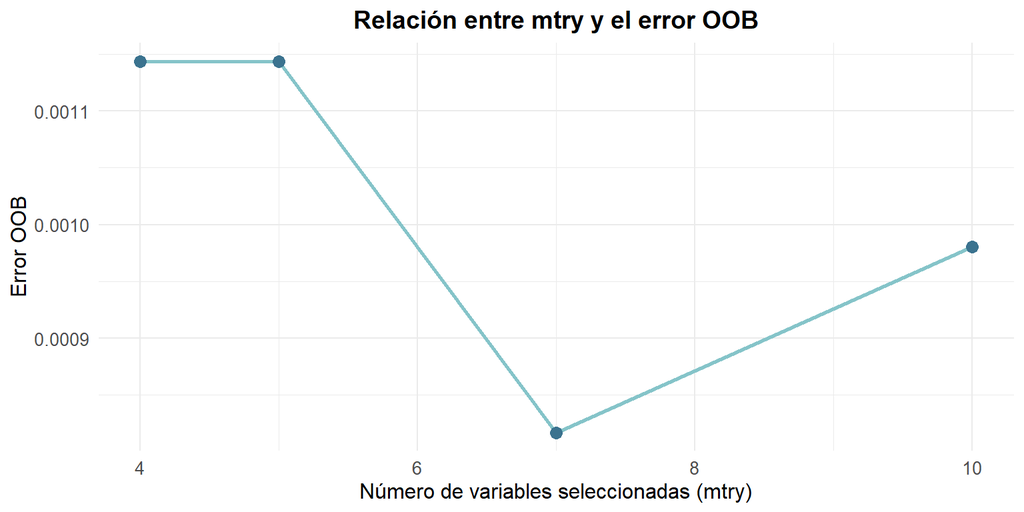

```r
mtry_df <- data.frame(
  mtry = mtry[, 1],
  OOB_Error = mtry[, 2]
)

# Crear el gráfico con ggplot2
ggplot(mtry_df, aes(x = mtry, y = OOB_Error)) +
  geom_line(color = colores[3], size = 1) +  # Línea
  geom_point(color = colores[6], size = 3) +  # Puntos
  labs(
    title = "Relación entre mtry y el error OOB",
    x = "Número de variables seleccionadas (mtry)",
    y = "Error OOB"
  ) +
  theme_minimal() +  # Tema limpio
  theme(
    plot.title = element_text(hjust = 0.5, size = 14, face = "bold"),  # Centrar título
    axis.title = element_text(size = 12),
    axis.text = element_text(size = 10)
  )
```

Los mejores mtry según el OOB error son el 7 y el 10 con un error de 0.0008 y 0.001, así que creamos dos nuevos modelos a evaluar:

```r
set.seed(123)
rf_m7 <- randomForest(Class ~ ., data = fraud_train, mtry=7)

set.seed(123)
rf_m10 <- randomForest(Class ~ ., data = fraud_train, mtry=10)

#save(rf_m7, rf_m10, file = "fraud_models.RData")
load("fraud_models.RData")
```

## 6. Predicción y evaluación de los modelos Random Forest

A continuación realizamos un cross validation para descubrir cuál de los modelos creados es el que tiene el mejor desempeño.

```r
calculate_metrics <- function(model, data, fold) {
  train_data <- data[-fold, ]
  test_data <- data[fold, ]

  set.seed(123)
  rf_model <- model(train_data)

  preds <- predict(rf_model, test_data)
  actual <- test_data$Class

  cm <- confusionMatrix(preds, actual, positive = "1")
  accuracy <- as.numeric(cm$overall['Accuracy'])
  recall <- as.numeric(cm$byClass['Recall'])

  return(c(accuracy, recall))
}

set.seed(123)
folds <- createFolds(fraud_train$Class, k = 5)

evaluate_model <- function(data, folds, model_func) {
  metrics <- lapply(folds, function(fold) calculate_metrics(model_func, data, fold))
  metrics_matrix <- do.call(rbind, metrics)
  colMeans(metrics_matrix)
}


models <- list(
  rf1 = function(data) randomForest(Class ~ ., data = data),
  rf_m7 = function(data) randomForest(Class ~ ., data = data, mtry = 7),
  rf_m10 = function(data) randomForest(Class ~ ., data = data, mtry = 10)
)

set.seed(123)
results <- lapply(models, function(model_func) evaluate_model(fraud_train, folds, model_func))

results_df <- data.frame(Model = names(results), do.call(rbind, results))
colnames(results_df) <- c("Model", "Accuracy", "Recall")
print(results_df)
```

```
        Model  Accuracy    Recall
rf1       rf1 0.9991833 0.9606154
rf_m7   rf_m7 0.9993465 0.9683077
rf_m10 rf_m10 0.9991833 0.9683077
```

Veamos su rendimiento con los datos aún no vistos del test set desbalanceado:

```r
set.seed(123)
rf_m7_eval <- predict(rf_m7, fraud_test)

confusion <- confusionMatrix(rf_m7_eval, fraud_test$Class, positive = "1")

confusion$table
```

```
          Reference
Prediction    0    1
         0 3988    3
         1    1    8
```

```r
confusion$overall["Accuracy"]
```

```
Accuracy
   0.999
```

```r
confusion$byClass["Recall"]
```

```
   Recall
0.7272727
```

```r
confusion$byClass["F1"]
```

```
 F1
0.8
```

Podemos comparar su rendimiento con el test set y con el método interno OOB:

```r
rf_m7$confusion[,1:2]
```

```
     0   1
0 5994   0
1    6 120
```

```r
table(" "=rf_m7_eval, fraud_test$Class)[,1:2]
```

```
       0    1
  0 3988    3
  1    1    8
```

Finalmente, sería interesante realizar más experimentos y análisis, incluyendo ajustes adicionales, como el uso de técnicas de balanceo de clases o validación cruzada en un conjunto más grande de datos, para evaluar el modelo en condiciones aún más diversas.

## 7. Referencias

[Colaboradores de Wikipedia. (2024, December 28). RMS Titanic. Wikipedia, La Enciclopedia Libre.](https://es.wikipedia.org/wiki/RMS_Titanic)

[La conexión de Cobh con el «Barco de los Sueños» (2024, December 9). Ireland.com.](https://www.ireland.com/es-es/magazine/built-heritage/titanic-in-cobh/)

[titanic package - RDocumentation. (n.d.).](https://www.rdocumentation.org/packages/titanic/versions/0.1.0)

[RPubs - Titanic. (n.d.).](https://rpubs.com/paraneda/titanic)

[RPubs - Introducción a la Validación Cruzada en R. (n.d.).](https://rpubs.com/rdelgado/405322)

[Perform cross-validation on train set or entire data set. (n.d.). Cross Validated.](https://stats.stackexchange.com/questions/339736/perform-cross-validation-on-train-set-or-entire-data-set)

A Collection of Oversampling Techniques for Class Imbalance Problem Based on SMOTE | March 14, 2024 | Wacharasak Siriseriwan

[Random Forests · AFIT Data Science Lab R Programming Guide. (n.d.).](https://afit-r.github.io/random_forests)